# Assignment 2

Milan Filipovic

April 13, 2021

```r
knitr::opts_chunk$set(echo = TRUE, cache = TRUE, fig.align = 'center')
```

## Question 1

*1.* Based on the introduction and variable list, complete the following sections of a Biostatistics Consulting Worksheet:

1. Date & Client Information
2. Purpose
3. Background & references
4. Descriptions

**Date**: 04/16/2021

**Client Information**:

- Name: William Northway, David Edwards, Thomas Colby, and Wayne Dyer
- Department: Stanford Medical Center
- Phone: 650-723-5721
- Name of principal investigator: William Northway, David Edwards, Thomas Colby, and Wayne Dyer, Stanford University

**Purpose**

- Statement of research hypothesis(es):
  - Factors associated with bronchopulmonary dysplasia (BPD) in newborn infants:
    1. Oxygen or intubation therapy cause BPD
    2. Pathological indices relate to BPD
    3. Background and health variables indicate high risk for contracting BPD
    4. BPD is serious to an infant’s life
- Statement of statistical hypothesis(es):
  1. Oxygen or intubation therapy cause BPD
     - Null hypothesis: Duration of oxygen or intubation therapy has no significant association with BPD
     - T-tests on log-transformed data for time length of oxygen or intubation therapy or logistic regression techniques can be used to assess association level with BPD.
  2. Pathological indices relate to BPD
     - Null hypothesis: Bronchiola mucosa, pulmonary interstitium, hyalin membranes, alveolar infiltrate, inflation pattern, BPD stage based on lung tissue, hematoidin have no significant association with BPD
     - Chi-square tests can be used to understand the associations between each pathological index with BPD, since these are discrete ordinal variables.
  3. Background and health variables indicate high risk for contracting BPD
     - Null hypothesis: Age, sex, year of birth, one-minute APGAR score, estimated gestational age, birthweight, and age at onset of respiratory symptoms have no significant association with BPD
     - Multiple logistic regression, t-tests or chi-square tests
  4. BPD is serious to an infant’s life
     - Null hypothesis: BPD is not significantly associated with survival or survival time
     - 2 proportion t-test given that we keep in mind differential follow-up times that might occur in this study sample.

**Background & references**:

- BPD is a respiratory problem that affects some newborn infants who have had respiratory distress syndrome (RDS) and subsequent oxygen therapy for it
- Oxygen or intubation therapy also suspected to cause BPD
- Severity of lung tissue deterioration measured on a scale of I to IV
- Stages I and II classified as not having BPD, stages III and IV classified as having BPD
- (Wolfe, “A Retrospective Study of Possible Causality Factors”)

**Descriptions**:

- Study design: Retrospective study
- Population(s): Newborn infants who have had RDS and subsequent oxygen therapy for it
- Sample(s): 299 infants treated at Stanford Medical center from 1962 – 1973 who had clinical and x-ray symptoms of RDS and received ventilatory assistance by intubation for over 24 hours
- Dependent variable(s):
  - Radiographic BPD score
  - Survival
  - Survival time
- Independent variable(s):
  - Background/Health variables
    - Age
    - Sex
    - Year of birth
    - One-minute APGAR score
    - Estimated gestational age
    - Birthweight
    - Age at onset of respiratory symptoms
    - RDS severity score
  - Measures of the therapy
    - Exposure to low concentrations of elevated oxygen
    - Exposure to medium concentrations of elevated oxygen
    - Exposure to high concentrations of elevated oxygen
    - Duration of endotracheal intubation
    - Duration of assisted ventilation
  - Pathological indices (only available for infants that died)
    - Bronchiola mucosa
    - Pulmonary interstitium
    - Hyalin membranes
    - Alveolar infiltrate
    - Inflation pattern
    - BPD stage based on lung tissue
    - Hematoidin

## Question 2

*2.* Briefly outline statistical procedures that may help answer the four main statistical questions listed on Page 105 of Wolfe's casebook study.

**Solution**:

The four statistical questions listed on Page 105 are as follows:

1. Do oxygen or intubation therapy cause BPD?
   - Need to address that we cannot assess causation from a retrospective study and clarify that with the researchers. Analyses should include only infants that lived long enough to contract BPD (the 248 infants who survived 3+ days).
   - T-tests on log-transformed data for time length of oxygen or intubation therapy or logistic regression techniques can be used to assess association level with BPD.
2. How are the pathological indices related to BPD?
   - Chi-square tests can be used to understand the associations between each pathological index with BPD, since these are discrete ordinal variables.
3. Which background or health variables indicates high risk for contracting BPD?
   - Multiple logistic regression can be used to assess the associations between all continuous and discrete ordinal variables and outcome of contracting BPD. Additionally, we can use t-tests and chi-square tests for continuous and discrete ordinal/categorical variables, respectively.
4. How serious is BPD to an infant's life?
   - 2 proportion t-test given that we keep in mind differential follow-up times that might occur in this study sample.
   - Simple chi-square tests comparing BPD stage to survival (dead or alive).

Brief statistical procedures that may help answer the four main statistical questions include t-test, chi-square tests, and multiple regression techniques. Initial descriptive statistics must be conducted to examine the data and analyze the appropriate sample.

```
## [1] "C:/Graduate School/Coursework/Spring 2021/402A/R projects/402A-spring2021"
```

```
## # A tibble: 299 x 24
##      pid   sex   bxy  agar  gage   bwt  rage  vage  idur  vdur   lo2   mo2   ho2
##    <dbl> <dbl> <dbl> <dbl> <dbl> <dbl> <dbl> <dbl> <dbl> <dbl> <dbl> <dbl> <dbl>
##  1     1     0    62    NA   370  2948     0    30    88    77   102    89     0
##  2     2     0    62    NA   360  2480     3    20   209   204     7   233     1
##  3     3     1    64    NA   310  1446     0     7    39    38     0     4    41
##  4     4     1    64    NA   300  2353     0     9    49    49     8    37    13
##  5     5     1    64     8   400  3203    10    58    41    40    79    26    31
##  6     6     1    64    NA   320  1860     0     1   653   644     0   625   156
##  7     7     1    64     9    NA  1701     5    49    40    40     0    12    79
##  8     8     0    64    NA   310  1417     5    17   103   102     0     3   119
##  9     9     1    64    10   350  2438     3    27    64    61   115   136    65
## 10    10     1    64     8   360  2020     0    28   147   146   438   416   435
## # ... with 289 more rows, and 11 more variables: cens <dbl>, surv <dbl>,
## #   rds <dbl>, bpd <dbl>, brmu <dbl>, puin <dbl>, hyme <dbl>, alin <dbl>,
## #   emph <dbl>, lbpd <dbl>, hema <dbl>
```

```
## Rows: 299
## Columns: 24
## $ pid  <dbl> 1, 2, 3, 4, 5, 6, 7, 8, 9, 10, 11, 12, 13, 14, 15, 16, 17, 18,...
## $ sex  <dbl> 0, 0, 1, 1, 1, 1, 1, 0, 1, 1, 0, 1, 1, 1, 1, 1, 1, 0, 0, 0, 1,...
## $ bxy  <dbl> 62, 62, 64, 64, 64, 64, 64, 64, 64, 64, 64, 64, 64, 64, 64, 64...
## $ agar <dbl> NA, NA, NA, NA, 8, NA, 9, NA, 10, 8, NA, NA, NA, 10, NA, NA, N...
## $ gage <dbl> 370, 360, 310, 300, 400, 320, NA, 310, 350, 360, 400, 240, 360...
## $ bwt  <dbl> 2948, 2480, 1446, 2353, 3203, 1860, 1701, 1417, 2438, 2020, 25...
## $ rage <dbl> 0, 3, 0, 0, 10, 0, 5, 5, 3, 0, 50, 0, 0, 0, 0, 0, 0, 0, 0, 0, ...
## $ vage <dbl> 30, 20, 7, 9, 58, 1, 49, 17, 27, 28, 49, 1, 34, 32, 31, 79, 40...
## $ idur <dbl> 88, 209, 39, 49, 41, 653, 40, 103, 64, 147, 90, 37, 31, 35, 22...
## $ vdur <dbl> 77, 204, 38, 49, 40, 644, 40, 102, 61, 146, 86, 37, 28, 32, 22...
## $ lo2  <dbl> 102, 7, 0, 8, 79, 0, 0, 0, 115, 438, 34, 0, 97, 56, 1214, 30, ...
## $ mo2  <dbl> 89, 233, 4, 37, 26, 625, 12, 3, 136, 416, 174, 0, 162, 47, 151...
## $ ho2  <dbl> 0, 1, 41, 13, 31, 156, 79, 119, 65, 435, 56, 37, 89, 132, 324,...
## $ cens <dbl> 1, 0, 0, 0, 1, 0, 0, 0, 1, 1, 1, 0, 1, 1, 0, 0, 0, 1, 1, 0, 1,...
## $ surv <dbl> 99999, 240, 45, 58, 94632, 796, 91, 122, 92568, 92376, 91656, ...
## $ rds  <dbl> 0, 1, 3, 5, 1, 2, 2, 5, 2, 3, 2, 5, 1, 3, 3, 1, 5, 1, 1, 2, 2,...
## $ bpd  <dbl> 10, 10, 10, 10, 10, 30, 10, 20, 10, 40, 10, 10, 10, 10, 40, 30...
## $ brmu <dbl> NA, 3, 1, 2, NA, 4, 3, 1, NA, NA, NA, 1, NA, NA, 0, 0, 4, NA, ...
## $ puin <dbl> NA, 2, 1, 1, NA, 4, 1, 1, NA, NA, NA, 1, NA, NA, 4, 4, 3, NA, ...
## $ hyme <dbl> NA, 4, 2, 4, NA, 0, 3, 3, NA, NA, NA, 3, NA, NA, 0, 0, 4, NA, ...
## $ alin <dbl> NA, 2, 1, 1, NA, 3, 1, 2, NA, NA, NA, 0, NA, NA, 3, 3, 3, NA, ...
## $ emph <dbl> NA, 3, 1, 1, NA, 4, 3, 1, NA, NA, NA, 0, NA, NA, 4, 4, 2, NA, ...
## $ lbpd <dbl> NA, 3, 1, 2, NA, 4, 2, 2, NA, NA, NA, 1, NA, NA, 4, 4, 3, NA, ...
## $ hema <dbl> NA, 0, 0, 0, NA, 0, 0, 2, NA, NA, NA, 0, NA, NA, 0, 0, 0, NA, ...
```

```
## # A tibble: 299 x 24
##      pid   sex   bxy  agar  gage   bwt  rage  vage  idur  vdur   lo2   mo2   ho2
##    <dbl> <dbl> <dbl> <dbl> <dbl> <dbl> <dbl> <dbl> <dbl> <dbl> <dbl> <dbl> <dbl>
##  1     1     0    62    NA   370  2948     0    30    88    77   102    89     0
##  2     2     0    62    NA   360  2480     3    20   209   204     7   233     1
##  3     3     1    64    NA   310  1446     0     7    39    38     0     4    41
##  4     4     1    64    NA   300  2353     0     9    49    49     8    37    13
##  5     5     1    64     8   400  3203    10    58    41    40    79    26    31
##  6     6     1    64    NA   320  1860     0     1   653   644     0   625   156
##  7     7     1    64     9    NA  1701     5    49    40    40     0    12    79
##  8     8     0    64    NA   310  1417     5    17   103   102     0     3   119
##  9     9     1    64    10   350  2438     3    27    64    61   115   136    65
## 10    10     1    64     8   360  2020     0    28   147   146   438   416   435
##     cens  surv   rds   bpd  brmu  puin  hyme  alin  emph  lbpd  hema
##    <dbl> <dbl> <dbl> <dbl> <dbl> <dbl> <dbl> <dbl> <dbl> <dbl> <dbl>
##  1     1 99999     0    10    NA    NA    NA    NA    NA    NA    NA
##  2     0   240     1    10     3     2     4     2     3     3     0
##  3     0    45     3    10     1     1     2     1     1     1     0
##  4     0    58     5    10     2     1     4     1     1     2     0
##  5     1 94632     1    10    NA    NA    NA    NA    NA    NA    NA
##  6     0   796     2    30     4     4     0     3     4     4     0
##  7     0    91     2    10     3     1     3     1     3     2     0
##  8     0   122     5    20     1     1     3     2     1     2     2
##  9     1 92568     2    10    NA    NA    NA    NA    NA    NA    NA
## 10     1 92376     3    40    NA    NA    NA    NA    NA    NA    NA
## # ... with 289 more rows
```

```
## # A tibble: 299 x 25
##      pid   sex   bxy  agar  gage   bwt  rage  vage  idur  vdur   lo2   mo2   ho2
##    <dbl> <dbl> <dbl> <dbl> <dbl> <dbl> <dbl> <dbl> <dbl> <dbl> <dbl> <dbl> <dbl>
##  1     1     0    62    NA   370  2948     0    30    88    77   102    89     0
##  2     2     0    62    NA   360  2480     3    20   209   204     7   233     1
##  3     3     1    64    NA   310  1446     0     7    39    38     0     4    41
##  4     4     1    64    NA   300  2353     0     9    49    49     8    37    13
##  5     5     1    64     8   400  3203    10    58    41    40    79    26    31
##  6     6     1    64    NA   320  1860     0     1   653   644     0   625   156
##  7     7     1    64     9    NA  1701     5    49    40    40     0    12    79
##  8     8     0    64    NA   310  1417     5    17   103   102     0     3   119
##  9     9     1    64    10   350  2438     3    27    64    61   115   136    65
## 10    10     1    64     8   360  2020     0    28   147   146   438   416   435
## # ... with 289 more rows, and 12 more variables: cens <dbl>, surv <dbl>,
## #   rds <dbl>, bpd <dbl>, brmu <dbl>, puin <dbl>, hyme <dbl>, alin <dbl>,
## #   emph <dbl>, lbpd <dbl>, hema <dbl>, gender <chr>
```

## Question 3

*3a.* Create a demographic table describing the study population. (Who was studied? How many were studied? To whom could you generalize results?) Include the following descriptions:

- % female; `gender`
- median and range of year of birth; `bxy`
- % APGAR scores; `agar`
- median and IQR gestational age; `gage`
- median and IQR birthweight; `bwt`
- median and IQR age at onset of respiratory symptoms; `rage`
- median and IQR age at onset of ventilatory assistance; `vage`

Demographic table had the study population split into with and without BPD, where with BPD included infants that reached at least stage III and without BPD included infants that did not reach stage III of disease progression.

```r
#
demographic_table <- BPD_tble %>%
  mutate(gender = ifelse(BPD_tble$sex == 1, "male", "female"),
          bpdyesno = ifelse(bpd >= 30, "w/ BPD", "w/o BPD")) %>%
  select(gender, bxy, agar, gage, bwt, rage, vage, cens, bpdyesno) %>%
  tbl_summary(by = bpdyesno,
              statistic = c("agar","gage","bwt", "rage", "vage") ~
              "{median} ({p25}, {p75})",
              digits = all_continuous() ~ 2,
              label = list(bxy ~ "Birth Year (Range:62 to 73)",
                 agar ~ "1-minute APGAR Score",
                 rage ~ "Age Onset of Respiratory Symptoms (Hoursx10)",
                 vage ~ "Age onset of Ventilatory Assistance (Hours)",
                 cens ~ "Survived as of May 1 1975"),
              missing_text = "Missing") %>%
  add_overall() %>%
  bold_labels() %>%
  modify_header(label ~ "**Table 1. Demographic Characteristics**" )
demographic_table
```

| **Table 1. Demographic Characteristics** | **Overall**, N = 299<sup>1</sup> | **w/ BPD**, N = 74<sup>1</sup> | **w/o BPD**, N = 225<sup>1</sup> |
| --- | --- | --- | --- |
| gender |  |  |  |
| female | 90 (30%) | 21 (28%) | 69 (31%) |
| male | 209 (70%) | 53 (72%) | 156 (69%) |
| Birth Year (Range:62 to 73) | 71.00 (67.00, 72.00) | 69.00 (67.00, 72.00) | 71.00 (68.00, 73.00) |
| 1-minute APGAR Score | 6.00 (4.00, 8.00) | 6.00 (4.00, 8.00) | 6.00 (3.00, 8.00) |
| Missing | 61 | 22 | 39 |
| gestational age, weeksX10 | 325.00 (300.00, 355.00) | 325.00 (310.00, 350.00) | 325.00 (300.00, 355.00) |
| Missing | 2 | 0 | 2 |
| birth weight, gms | 1,701.00 (1,288.00, 2,264.00) | 1,778.00 (1,360.00, 2,232.75) | 1,673.00 (1,250.00, 2,268.00) |
| Age Onset of Respiratory Symptoms (Hoursx10) | 0.00 (0.00, 5.00) | 0.00 (0.00, 3.00) | 0.00 (0.00, 5.00) |
| Missing | 3 | 0 | 3 |
| Age onset of Ventilatory Assistance (Hours) | 20.00 (8.00, 36.00) | 26.50 (13.25, 43.00) | 19.00 (8.00, 34.00) |
| Survived as of May 1 1975 | 140 (47%) | 37 (50%) | 103 (46%) |

<sup>*1*</sup> n (%); Median (IQR)

*3b.* Plots (histograms or box plots) and summary statistics for the distributions of:

1. hours of exposure to low concentrations of elevated oxygen
2. hours of exposure to medium concentrations of elevated oxygen
3. hours of exposure to high concentrations of elevated oxygen
4. hours of duration of endotracheal intubation
5. hours of duration of assisted ventilation

**Solution**

**i.** Hours of exposure to low concentrations of elevated oxygen

```r
summary(BPD_tble$lo2)
```

```
##    Min. 1st Qu.  Median    Mean 3rd Qu.    Max.
##     0.0     0.0    52.0   275.5   196.5 11106.0
```

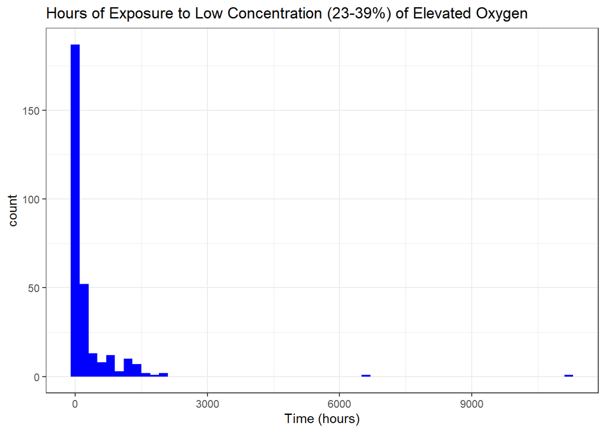

```r
BPD_tble %>% ggplot(mapping = aes(x = lo2)) +
  geom_histogram(binwidth = 200, fill="blue")+
  ggtitle("Hours of Exposure to Low Concentration (23-39%) of Elevated Oxygen") +
  labs(x = "Time (hours)") +
  theme_bw()
```

We see that the distribution is right skewed, with outliers at the high extreme.

**ii.** Hours of exposure to medium concentrations of elevated oxygen

```r
summary(BPD_tble$mo2)
```

```
##    Min. 1st Qu.  Median    Mean 3rd Qu.    Max.
##     0.0    23.5    79.0   184.8   156.5  3640.0
```

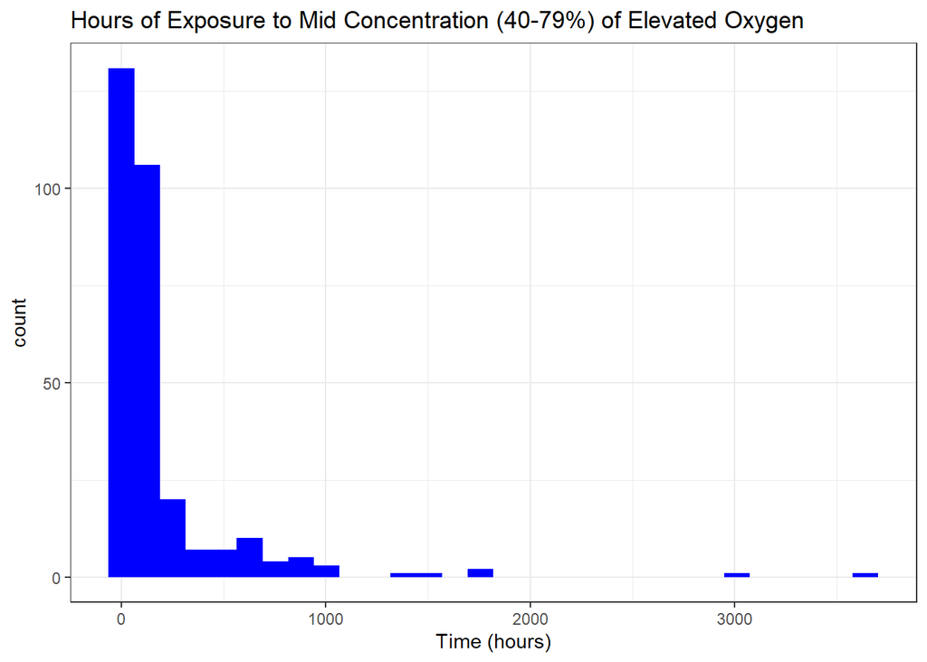

```r
BPD_tble %>% ggplot(mapping = aes(x = mo2)) +
  geom_histogram(fill="blue")+
  labs(x = "Time (hours)") +
  ggtitle("Hours of Exposure to Mid Concentration (40-79%) of Elevated Oxygen") +
  theme_bw()
```

**iii.** Hours of exposure to high concentrations of elevated oxygen

```r
summary(BPD_tble$ho2)
```

```
##    Min. 1st Qu.  Median    Mean 3rd Qu.    Max.
##    0.00   16.00   41.00   79.27   94.00 1083.00
```

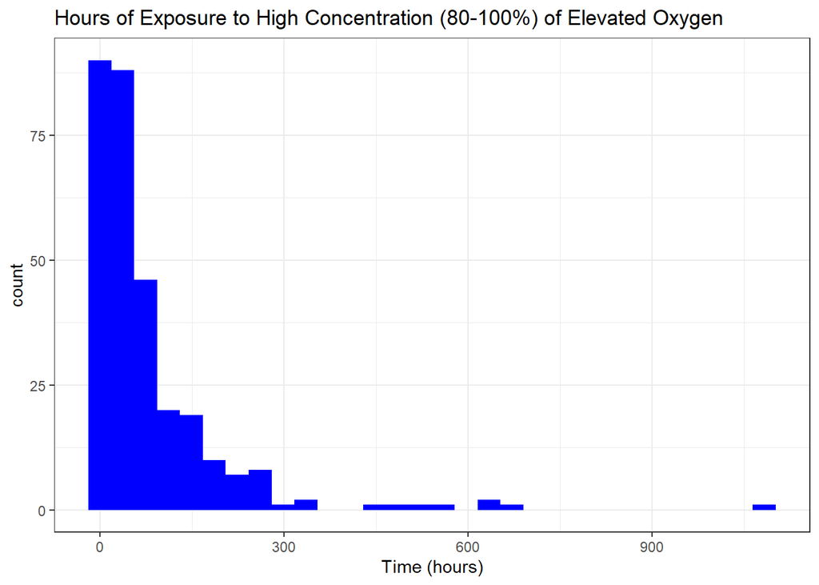

```r
BPD_tble %>% ggplot(mapping = aes(x = ho2)) +
  geom_histogram(fill="blue") +
  labs(x = "Time (hours)") +
  ggtitle("Hours of Exposure to High Concentration (80-100%) of Elevated Oxygen") +
  theme_bw()
```

This distribution is also right skewed. The scale of time is much lower then mid and low oxygen exposure.

**iv.** Hours of duration of endotracheal intubation

Next we examine the distribution of the duration of endotracheal intubation `idur`.

```r
summary(BPD_tble$idur)
```

```
##    Min. 1st Qu.  Median    Mean 3rd Qu.    Max.
##    24.0    63.5   137.0   225.7   236.0  2345.0
```

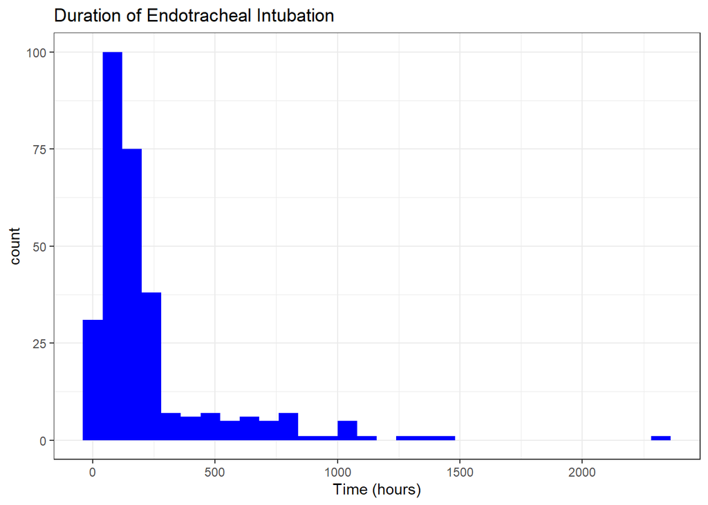

```r
BPD_tble %>% ggplot(mapping = aes(x = idur)) +
  geom_histogram(fill = "blue") +
  labs(x = "Time (hours)") +
  ggtitle("Duration of Endotracheal Intubation") +
  theme_bw()
```

The distribution appears heavily right skewed, with many potential outliers.

**v.** Hours of duration of assisted ventilation

Next we examine the distribution of the duration of assisted ventilation intubation `vdur`.

```r
summary(BPD_tble$vdur)
```

```
##    Min. 1st Qu.  Median    Mean 3rd Qu.    Max.    NA's
##    24.0    61.0   120.5   210.2   221.2  2012.0       1
```

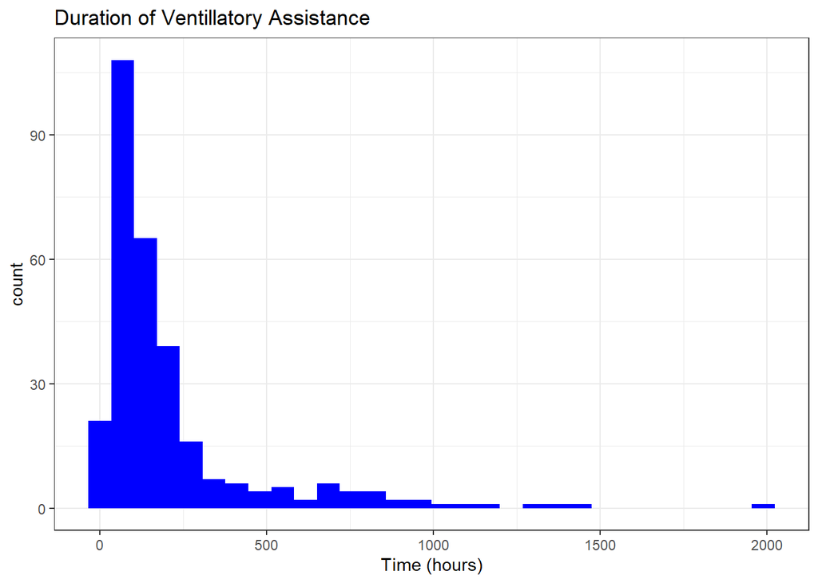

```r
BPD_tble %>% ggplot(mapping = aes(x = vdur)) +
  geom_histogram(fill = "blue") +
  labs(x = "Time (hours)") +
  ggtitle("Duration of Ventillatory Assistance") +
  theme_bw()
```

```r
BPD_tble %>% select(lo2, mo2, ho2, idur, vdur) %>%
  summary()
```

```
##       lo2               mo2              ho2               idur
##  Min.   :    0.0   Min.   :   0.0   Min.   :   0.00   Min.   :  24.0
##  1st Qu.:    0.0   1st Qu.:  23.5   1st Qu.:  16.00   1st Qu.:  63.5
##  Median :   52.0   Median :  79.0   Median :  41.00   Median : 137.0
##  Mean   :  275.5   Mean   : 184.8   Mean   :  79.27   Mean   : 225.7
##  3rd Qu.:  196.5   3rd Qu.: 156.5   3rd Qu.:  94.00   3rd Qu.: 236.0
##  Max.   :11106.0   Max.   :3640.0   Max.   :1083.00   Max.   :2345.0
##
##       vdur
##  Min.   :  24.0
##  1st Qu.:  61.0
##  Median : 120.5
##  Mean   : 210.2
##  3rd Qu.: 221.2
##  Max.   :2012.0
##  NA's   :1
```

We see that for all variables the mean is larger than the median, indicating right skew. Note also in lo2 the first quartile is 0, indicating many values of zero.

3. Counts (or bar graphs) of RDS and radiographic BPD scores. How many infants were classified as having RDS, very severe RDS, and BPD?

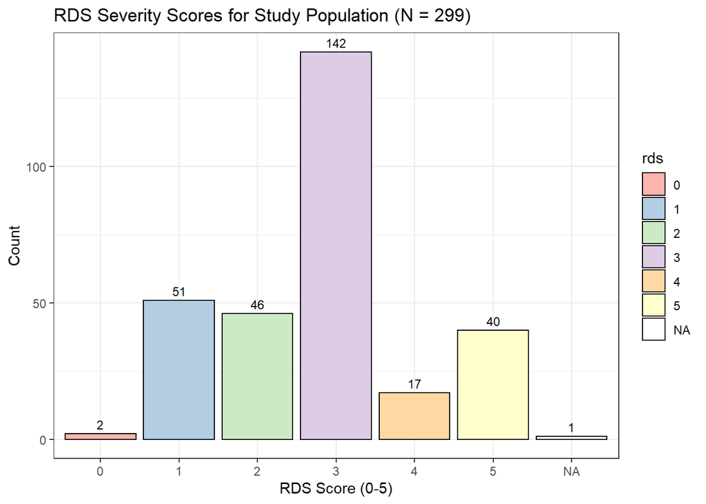

```r
# rds
BPD_tble %>%
  mutate(rds = as.factor(rds)) %>%
  ggplot(mapping = aes(rds)) +
  geom_bar(aes(fill = rds), colour = "black") +
  scale_fill_brewer(palette = "Pastel1") +
  labs(x = "RDS Score (0-5)", y = "Count",
       title = "RDS Severity Scores for Study Population (N = 299)") +
  geom_text(stat = "count", aes(label = ..count..), vjust = -0.5, size = 3) +
  theme_bw()
```

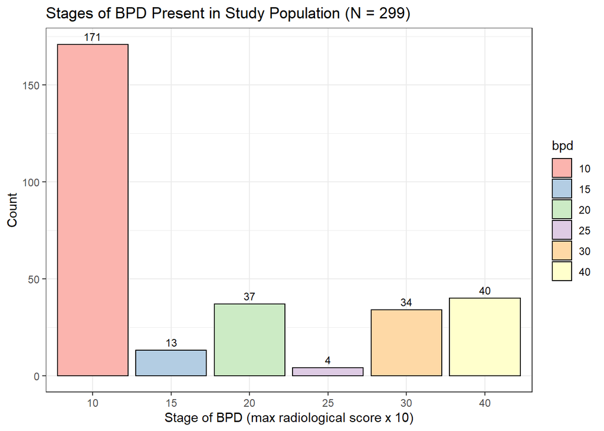

```r
# bpd
BPD_tble %>%
  mutate(bpd = as.factor(bpd)) %>%
  ggplot(mapping = aes(bpd)) +
  geom_bar(aes(fill = bpd), colour = "black") +
  scale_fill_brewer(palette = "Pastel1") +
  labs(x = "Stage of BPD (max radiological score x 10)", y = "Count",
       title = "Stages of BPD Present in Study Population (N = 299)") +
  geom_text(stat = "count", aes(label = ..count..), vjust = -0.5, size = 3) +
  theme_bw()
```

4. Missing data and outliers. Identify variables with large numbers of missing data values (say, >20% missing). List variables with extreme outliers.

Identifying variables with > 20% missing for a dataset containing 299 observations is equivalent to identifying variables with > 60 missing values. We see that in the bpd data set, 8 variables (`agar`, `brmu`, `puin`, `hyme`. `alin`, `emph`, `lbpd`, `hema`) have more than 60 missing values.

```r
# NA counts for each variable
missing <- BPD_tble %>%
  select(everything()) %>%
  summarise_all(funs(sum(is.na(.)))) %>%
  print(width = Inf)
```

```
## # A tibble: 1 x 24
##     pid   sex   bxy  agar  gage   bwt  rage  vage  idur  vdur   lo2   mo2   ho2
##   <int> <int> <int> <int> <int> <int> <int> <int> <int> <int> <int> <int> <int>
## 1     0     0     0    61     2     0     3     0     0     1     0     0     0
##    cens  surv   rds   bpd  brmu  puin  hyme  alin  emph  lbpd  hema
##   <int> <int> <int> <int> <int> <int> <int> <int> <int> <int> <int>
## 1     0     0     1     0   157   157   157   157   157   157   157
```

```r
# extreme outlier identification
# excluded pid since pid is unique
# variables with 5 unique values or less were excluded

df <- reshape2::melt(BPD_tble[,-c(1,2, 14, 18:24)])
```

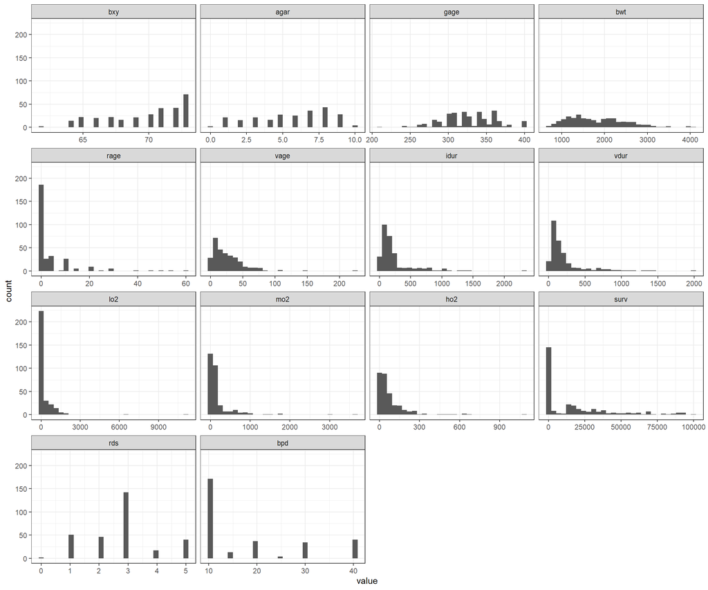

```r
ggplot(df, aes(x = value)) +
  facet_wrap(~variable, scales = "free_x") +
  geom_histogram() +
  theme_bw()
```

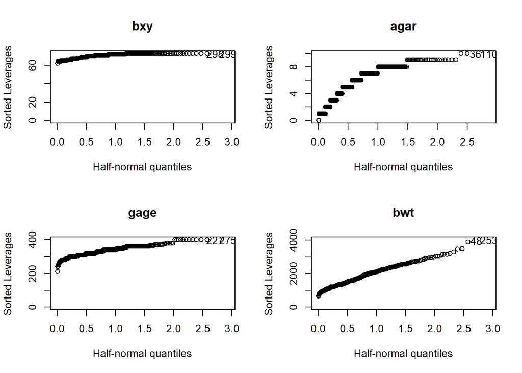

```r
par(mfrow = c(2,2))
halfnorm(BPD_tble$bxy, ylab = "Sorted Leverages")
title(main = "bxy")
halfnorm(BPD_tble$agar, ylab = "Sorted Leverages")
title(main = "agar")
halfnorm(BPD_tble$gage, ylab = "Sorted Leverages")
title(main = "gage")
halfnorm(BPD_tble$bwt, ylab = "Sorted Leverages")
title(main = "bwt")
```

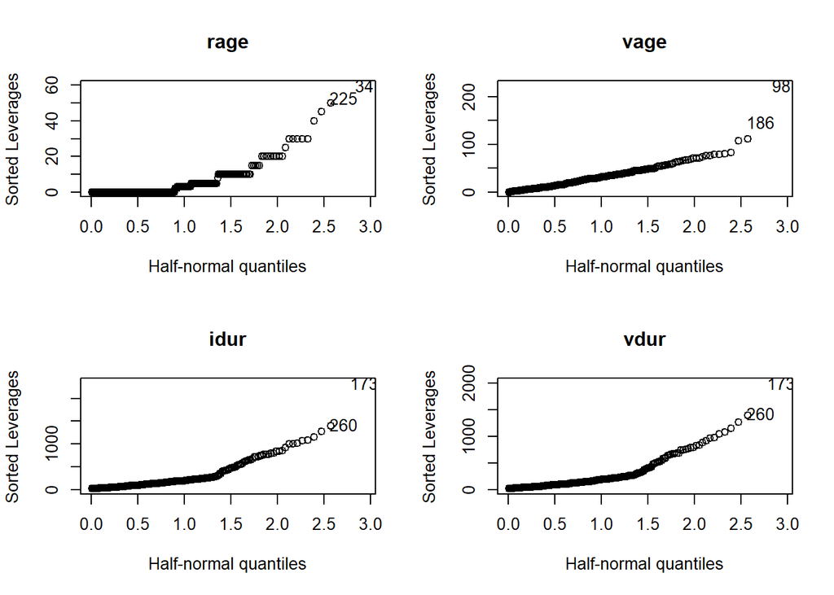

```r
halfnorm(BPD_tble$rage, ylab = "Sorted Leverages")
title(main = "rage")
halfnorm(BPD_tble$vage, ylab = "Sorted Leverages")
title(main = "vage")
halfnorm(BPD_tble$idur, ylab = "Sorted Leverages")
title(main = "idur")
halfnorm(BPD_tble$vdur, ylab = "Sorted Leverages")
title(main = "vdur")
```

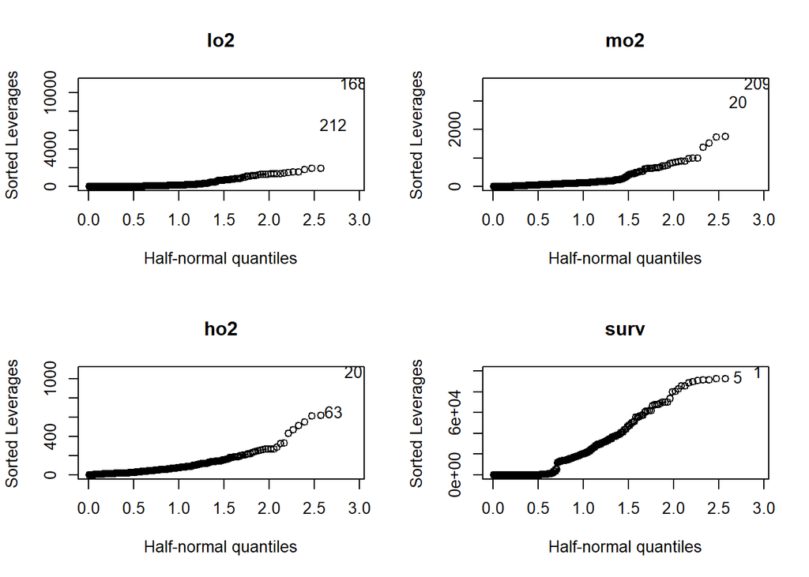

```
## [1] "Influential Observations in agar"
```

```
## # A tibble: 2 x 22
##     pid   bxy  agar  gage   bwt  rage  vage  idur  vdur   lo2   mo2   ho2  surv
##   <dbl> <dbl> <dbl> <dbl> <dbl> <dbl> <dbl> <dbl> <dbl> <dbl> <dbl> <dbl> <dbl>
## 1    36    65    10   360  2208    45    19    40    40     3    31    37    70
## 2   110    69    10   365  2552    10    14   148   101    12   146    63 50208
## # ... with 9 more variables: rds <dbl>, bpd <dbl>, brmu <dbl>, puin <dbl>,
## #   hyme <dbl>, alin <dbl>, emph <dbl>, lbpd <dbl>, hema <dbl>
```

```
## [1] "Influential Observations in bwt"
```

```
## # A tibble: 2 x 22
##     pid   bxy  agar  gage   bwt  rage  vage  idur  vdur   lo2   mo2   ho2  surv
##   <dbl> <dbl> <dbl> <dbl> <dbl> <dbl> <dbl> <dbl> <dbl> <dbl> <dbl> <dbl> <dbl>
## 1    48    66    NA   400  3969     0    15    48    43     0     7    56    63
## 2   254    73     7   360  4026     3     4   221   219   665   200    24 16704
## # ... with 9 more variables: rds <dbl>, bpd <dbl>, brmu <dbl>, puin <dbl>,
## #   hyme <dbl>, alin <dbl>, emph <dbl>, lbpd <dbl>, hema <dbl>
```

```
## [1] "Influential Observations in rage"
```

```
## # A tibble: 2 x 22
##     pid   bxy  agar  gage   bwt  rage  vage  idur  vdur   lo2   mo2   ho2  surv
##   <dbl> <dbl> <dbl> <dbl> <dbl> <dbl> <dbl> <dbl> <dbl> <dbl> <dbl> <dbl> <dbl>
## 1    34    65     9   340  2041    60    55   411   307  1318  1724   331  3360
## 2   226    72     9   370  3487    53    38    42    42    39    53     7 21360
## # ... with 9 more variables: rds <dbl>, bpd <dbl>, brmu <dbl>, puin <dbl>,
## #   hyme <dbl>, alin <dbl>, emph <dbl>, lbpd <dbl>, hema <dbl>
```

```
## [1] "Influential Observations in vage"
```

```
## # A tibble: 2 x 22
##     pid   bxy  agar  gage   bwt  rage  vage  idur  vdur   lo2   mo2   ho2  surv
##   <dbl> <dbl> <dbl> <dbl> <dbl> <dbl> <dbl> <dbl> <dbl> <dbl> <dbl> <dbl> <dbl>
## 1    98    69     1   310  1260     0   224   260    54   127   331     0 55272
## 2   187    71     6   360  1587    10   147   134   126   203   218     4   424
## # ... with 9 more variables: rds <dbl>, bpd <dbl>, brmu <dbl>, puin <dbl>,
## #   hyme <dbl>, alin <dbl>, emph <dbl>, lbpd <dbl>, hema <dbl>
```

```
## [1] "Influential Observations in idur and vdur"
```

```
## # A tibble: 2 x 22
##     pid   bxy  agar  gage   bwt  rage  vage  idur  vdur   lo2   mo2   ho2  surv
##   <dbl> <dbl> <dbl> <dbl> <dbl> <dbl> <dbl> <dbl> <dbl> <dbl> <dbl> <dbl> <dbl>
## 1   174    71     5   300  1360     0    12  2345  2012  1901   367   211 31963
## 2   261    73     7   300  1587     0    12  1436  1436   622   973    10 15744
## # ... with 9 more variables: rds <dbl>, bpd <dbl>, brmu <dbl>, puin <dbl>,
## #   hyme <dbl>, alin <dbl>, emph <dbl>, lbpd <dbl>, hema <dbl>
```

```
## [1] "Influential Observations in lo2"
```

```
## # A tibble: 2 x 22
##     pid   bxy  agar  gage   bwt  rage  vage  idur  vdur   lo2   mo2   ho2  surv
##   <dbl> <dbl> <dbl> <dbl> <dbl> <dbl> <dbl> <dbl> <dbl> <dbl> <dbl> <dbl> <dbl>
## 1   169    71     6   320  1928     0    68   192   189 11106   652    86 29688
## 2   213    72    NA   340  1106     0     3  1076  1042  6662  1747    77 11808
## # ... with 9 more variables: rds <dbl>, bpd <dbl>, brmu <dbl>, puin <dbl>,
## #   hyme <dbl>, alin <dbl>, emph <dbl>, lbpd <dbl>, hema <dbl>
```

```
## [1] "Influential Observations in mo2"
```

```
## # A tibble: 2 x 22
##     pid   bxy  agar  gage   bwt  rage  vage  idur  vdur   lo2   mo2   ho2  surv
##   <dbl> <dbl> <dbl> <dbl> <dbl> <dbl> <dbl> <dbl> <dbl> <dbl> <dbl> <dbl> <dbl>
## 1    20    65    NA   260  1091     0     0   922   918  1370  2969  1083  5424
## 2   210    72     5   300  2090     3    68   679   659  1480  3640   102  5208
## # ... with 9 more variables: rds <dbl>, bpd <dbl>, brmu <dbl>, puin <dbl>,
## #   hyme <dbl>, alin <dbl>, emph <dbl>, lbpd <dbl>, hema <dbl>
```

```
## [1] "Influential Observations in ho2"
```

```
## # A tibble: 2 x 22
##     pid   bxy  agar  gage   bwt  rage  vage  idur  vdur   lo2   mo2   ho2  surv
##   <dbl> <dbl> <dbl> <dbl> <dbl> <dbl> <dbl> <dbl> <dbl> <dbl> <dbl> <dbl> <dbl>
## 1    20    65    NA   260  1091     0     0   922   918  1370  2969  1083  5424
## 2    63    67    NA   365  2197     0    44   753   753     3   483   659  1149
## # ... with 9 more variables: rds <dbl>, bpd <dbl>, brmu <dbl>, puin <dbl>,
## #   hyme <dbl>, alin <dbl>, emph <dbl>, lbpd <dbl>, hema <dbl>
```

```
## [1] "Influential Observations in surv"
```

```
## # A tibble: 2 x 22
##     pid   bxy  agar  gage   bwt  rage  vage  idur  vdur   lo2   mo2   ho2  surv
##   <dbl> <dbl> <dbl> <dbl> <dbl> <dbl> <dbl> <dbl> <dbl> <dbl> <dbl> <dbl> <dbl>
## 1     5    64     8   400  3203    10    58    41    40    79    26    31 94632
## 2     1    62    NA   370  2948     0    30    88    77   102    89     0 99999
## # ... with 9 more variables: rds <dbl>, bpd <dbl>, brmu <dbl>, puin <dbl>,
## #   hyme <dbl>, alin <dbl>, emph <dbl>, lbpd <dbl>, hema <dbl>
```

```r
halfnorm(BPD_tble$lo2, ylab = "Sorted Leverages")
title(main = "lo2")
halfnorm(BPD_tble$mo2, ylab = "Sorted Leverages")
title(main = "mo2")
halfnorm(BPD_tble$ho2, ylab = "Sorted Leverages")
title(main = "ho2")
halfnorm(BPD_tble$surv, ylab = "Sorted Leverages")
title(main = "surv")
```